# Risk Factor Analysis

## Outcome Variable

**Outcome Variable:** stunted

## Predictor Variables

**Intervention Variable:** feducyrs

**Adjustment Set:**

- arm
- W_mage
- meducyrs
- hhwealth_quart
- W_mhtcm
- W_mwtkg
- W_mbmi
- W_gagebrth
- W_birthwt
- W_birthlen
- single
- impsan
- delta_W_mage
- delta_meducyrs
- delta_hhwealth_quart
- delta_W_mhtcm
- delta_W_mwtkg
- delta_W_mbmi
- delta_W_gagebrth
- delta_W_birthwt
- delta_W_birthlen
- delta_single
- delta_impsan

## Stratifying Variables

The analysis was stratified on these variable(s):

- agecat
- studyid
- country

## Data Summary

| agecat | studyid | country | feducyrs | stunted | n_cell | n |
| --- | --- | --- | --- | --- | --- | --- |
| Birth | ki0047075b-MAL-ED | BANGLADESH | High | 0 | 39 | 129 |
| Birth | ki0047075b-MAL-ED | BANGLADESH | High | 1 | 8 | 129 |
| Birth | ki0047075b-MAL-ED | BANGLADESH | Low | 0 | 28 | 129 |
| Birth | ki0047075b-MAL-ED | BANGLADESH | Low | 1 | 8 | 129 |
| Birth | ki0047075b-MAL-ED | BANGLADESH | Medium | 0 | 36 | 129 |
| Birth | ki0047075b-MAL-ED | BANGLADESH | Medium | 1 | 10 | 129 |
| Birth | ki0047075b-MAL-ED | INDIA | High | 0 | 6 | 24 |
| Birth | ki0047075b-MAL-ED | INDIA | High | 1 | 1 | 24 |
| Birth | ki0047075b-MAL-ED | INDIA | Low | 0 | 13 | 24 |
| Birth | ki0047075b-MAL-ED | INDIA | Low | 1 | 1 | 24 |
| Birth | ki0047075b-MAL-ED | INDIA | Medium | 0 | 3 | 24 |
| Birth | ki0047075b-MAL-ED | INDIA | Medium | 1 | 0 | 24 |
| Birth | ki0047075b-MAL-ED | NEPAL | High | 0 | 2 | 10 |
| Birth | ki0047075b-MAL-ED | NEPAL | High | 1 | 1 | 10 |
| Birth | ki0047075b-MAL-ED | NEPAL | Low | 0 | 3 | 10 |
| Birth | ki0047075b-MAL-ED | NEPAL | Low | 1 | 1 | 10 |
| Birth | ki0047075b-MAL-ED | NEPAL | Medium | 0 | 3 | 10 |
| Birth | ki0047075b-MAL-ED | NEPAL | Medium | 1 | 0 | 10 |
| Birth | ki0047075b-MAL-ED | PERU | High | 0 | 79 | 194 |
| Birth | ki0047075b-MAL-ED | PERU | High | 1 | 7 | 194 |
| Birth | ki0047075b-MAL-ED | PERU | Low | 0 | 47 | 194 |
| Birth | ki0047075b-MAL-ED | PERU | Low | 1 | 11 | 194 |
| Birth | ki0047075b-MAL-ED | PERU | Medium | 0 | 47 | 194 |
| Birth | ki0047075b-MAL-ED | PERU | Medium | 1 | 3 | 194 |
| Birth | ki0047075b-MAL-ED | SOUTH AFRICA | High | 0 | 10 | 33 |
| Birth | ki0047075b-MAL-ED | SOUTH AFRICA | High | 1 | 0 | 33 |
| Birth | ki0047075b-MAL-ED | SOUTH AFRICA | Low | 0 | 14 | 33 |
| Birth | ki0047075b-MAL-ED | SOUTH AFRICA | Low | 1 | 0 | 33 |
| Birth | ki0047075b-MAL-ED | SOUTH AFRICA | Medium | 0 | 8 | 33 |
| Birth | ki0047075b-MAL-ED | SOUTH AFRICA | Medium | 1 | 1 | 33 |

[output cut: 300 more lines]

The following strata were considered:

- agecat: 24 months, studyid: ki0047075b-MAL-ED, country: BANGLADESH
- agecat: 24 months, studyid: ki0047075b-MAL-ED, country: INDIA
- agecat: 24 months, studyid: ki0047075b-MAL-ED, country: NEPAL
- agecat: 24 months, studyid: ki0047075b-MAL-ED, country: PERU
- agecat: 24 months, studyid: ki0047075b-MAL-ED, country: SOUTH AFRICA
- agecat: 24 months, studyid: ki0047075b-MAL-ED, country: TANZANIA, UNITED REPUBLIC OF
- agecat: 24 months, studyid: ki1017093b-PROVIDE, country: BANGLADESH
- agecat: 24 months, studyid: ki1017093c-NIH-Crypto, country: BANGLADESH
- agecat: 24 months, studyid: ki1066203-TanzaniaChild2, country: TANZANIA, UNITED REPUBLIC OF
- agecat: 24 months, studyid: ki1113344-GMS-Nepal, country: NEPAL
- agecat: 24 months, studyid: ki1119695-PROBIT, country: BELARUS
- agecat: 24 months, studyid: ki1126311-ZVITAMBO, country: ZIMBABWE
- agecat: 24 months, studyid: ki1135781-COHORTS, country: GUATEMALA
- agecat: 24 months, studyid: ki1135781-COHORTS, country: INDIA
- agecat: 24 months, studyid: ki1135781-COHORTS, country: PHILIPPINES
- agecat: 24 months, studyid: ki1148112-LCNI-5, country: MALAWI
- agecat: 24 months, studyid: kiGH5241-JiVitA-3, country: BANGLADESH
- agecat: 24 months, studyid: kiGH5241-JiVitA-4, country: BANGLADESH
- agecat: 6 months, studyid: ki0047075b-MAL-ED, country: BANGLADESH
- agecat: 6 months, studyid: ki0047075b-MAL-ED, country: INDIA
- agecat: 6 months, studyid: ki0047075b-MAL-ED, country: NEPAL
- agecat: 6 months, studyid: ki0047075b-MAL-ED, country: PERU
- agecat: 6 months, studyid: ki0047075b-MAL-ED, country: SOUTH AFRICA
- agecat: 6 months, studyid: ki0047075b-MAL-ED, country: TANZANIA, UNITED REPUBLIC OF
- agecat: 6 months, studyid: ki1000304b-SAS-CompFeed, country: INDIA
- agecat: 6 months, studyid: ki1000304b-SAS-FoodSuppl, country: INDIA
- agecat: 6 months, studyid: ki1017093b-PROVIDE, country: BANGLADESH
- agecat: 6 months, studyid: ki1017093c-NIH-Crypto, country: BANGLADESH
- agecat: 6 months, studyid: ki1066203-TanzaniaChild2, country: TANZANIA, UNITED REPUBLIC OF
- agecat: 6 months, studyid: ki1113344-GMS-Nepal, country: NEPAL
- agecat: 6 months, studyid: ki1119695-PROBIT, country: BELARUS
- agecat: 6 months, studyid: ki1126311-ZVITAMBO, country: ZIMBABWE
- agecat: 6 months, studyid: ki1135781-COHORTS, country: GUATEMALA
- agecat: 6 months, studyid: ki1135781-COHORTS, country: INDIA
- agecat: 6 months, studyid: ki1135781-COHORTS, country: PHILIPPINES
- agecat: 6 months, studyid: ki1148112-LCNI-5, country: MALAWI
- agecat: 6 months, studyid: kiGH5241-JiVitA-3, country: BANGLADESH
- agecat: 6 months, studyid: kiGH5241-JiVitA-4, country: BANGLADESH
- agecat: Birth, studyid: ki0047075b-MAL-ED, country: BANGLADESH
- agecat: Birth, studyid: ki0047075b-MAL-ED, country: INDIA
- agecat: Birth, studyid: ki0047075b-MAL-ED, country: NEPAL
- agecat: Birth, studyid: ki0047075b-MAL-ED, country: PERU
- agecat: Birth, studyid: ki0047075b-MAL-ED, country: SOUTH AFRICA
- agecat: Birth, studyid: ki0047075b-MAL-ED, country: TANZANIA, UNITED REPUBLIC OF
- agecat: Birth, studyid: ki1000304b-SAS-CompFeed, country: INDIA
- agecat: Birth, studyid: ki1017093b-PROVIDE, country: BANGLADESH
- agecat: Birth, studyid: ki1017093c-NIH-Crypto, country: BANGLADESH
- agecat: Birth, studyid: ki1113344-GMS-Nepal, country: NEPAL
- agecat: Birth, studyid: ki1119695-PROBIT, country: BELARUS
- agecat: Birth, studyid: ki1126311-ZVITAMBO, country: ZIMBABWE
- agecat: Birth, studyid: ki1135781-COHORTS, country: GUATEMALA
- agecat: Birth, studyid: ki1135781-COHORTS, country: INDIA
- agecat: Birth, studyid: ki1135781-COHORTS, country: PHILIPPINES
- agecat: Birth, studyid: kiGH5241-JiVitA-3, country: BANGLADESH
- agecat: Birth, studyid: kiGH5241-JiVitA-4, country: BANGLADESH

### Dropped Strata

Some strata were dropped due to rare outcomes:

- agecat: Birth, studyid: ki0047075b-MAL-ED, country: INDIA
- agecat: Birth, studyid: ki0047075b-MAL-ED, country: NEPAL
- agecat: Birth, studyid: ki0047075b-MAL-ED, country: PERU
- agecat: Birth, studyid: ki0047075b-MAL-ED, country: SOUTH AFRICA
- agecat: Birth, studyid: ki0047075b-MAL-ED, country: TANZANIA, UNITED REPUBLIC OF
- agecat: Birth, studyid: ki1119695-PROBIT, country: BELARUS
- agecat: 6 months, studyid: ki0047075b-MAL-ED, country: NEPAL
- agecat: 6 months, studyid: ki0047075b-MAL-ED, country: SOUTH AFRICA
- agecat: 24 months, studyid: ki0047075b-MAL-ED, country: TANZANIA, UNITED REPUBLIC OF
- agecat: 24 months, studyid: ki1066203-TanzaniaChild2, country: TANZANIA, UNITED REPUBLIC OF

## Methods Detail

We’re interested in the causal parameters $E[Y_a]$ for all values of $a \in \mathcal{A}$. These parameters represent the mean outcome if, possibly contrary to fact, we intervened to set all units to have $A=a$. Under the randomization and positivity assumptions, these are identified by the statistical parameters $\psi_a=E_W[E_{Y|A,W}(Y|A=a,W)]$. In addition, we’re interested in the mean of $Y$, $E[Y]$ under no intervention (the observed mean). We will estimate these parameters by using SuperLearner to fit the relevant likelihood factors – $E_{Y|A,W}(Y|A=a,W)$ and $p(A=a|W)$, and then updating our likelihood fit using a joint TMLE.

For unadjusted analyses ($W=\{\}$), initial likelihoods were estimated using Lrnr_glm to estimate the simple $E(Y|A)$ and Lrnr_mean to estimate $p(A)$. For adjusted analyses, a small library containing Lrnr_glmnet, Lrnr_xgboost, and Lrnr_mean was used.

Having estimated these parameters, we will then use the delta method to estimate relative risks and attributable risks relative to a prespecified baseline level of $A$.

# Results Detail

## Results Plots

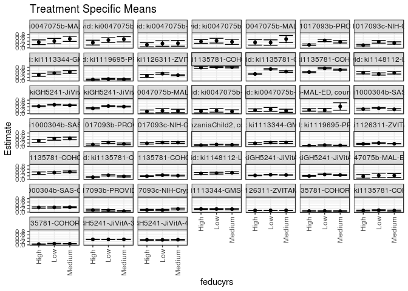

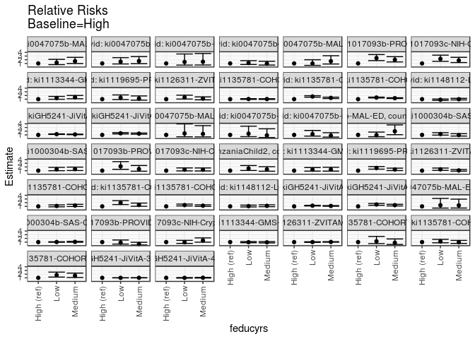

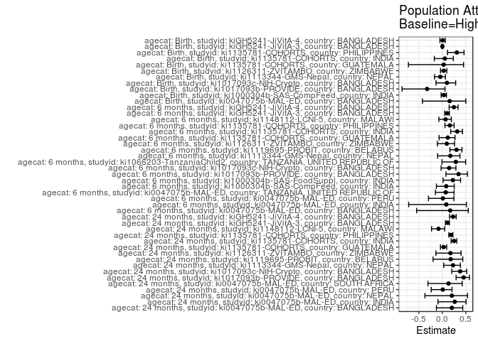

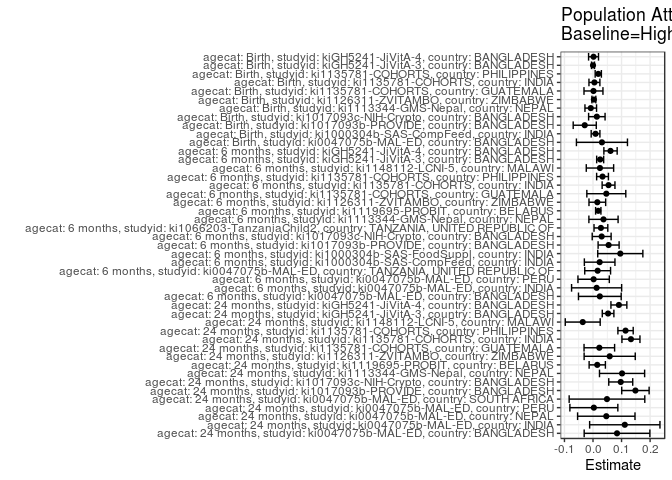

## Results Table

### Parameter: TSM

| agecat | studyid | country | intervention_level | baseline_level | estimate | ci_lower | ci_upper |
| --- | --- | --- | --- | --- | --- | --- | --- |
| Birth | ki0047075b-MAL-ED | BANGLADESH | High | NA | 0.1702128 | 0.0623508 | 0.2780748 |
| Birth | ki0047075b-MAL-ED | BANGLADESH | Low | NA | 0.2222222 | 0.0858870 | 0.3585575 |
| Birth | ki0047075b-MAL-ED | BANGLADESH | Medium | NA | 0.2173913 | 0.0977303 | 0.3370523 |
| Birth | ki1000304b-SAS-CompFeed | INDIA | High | NA | 0.2697131 | 0.2301329 | 0.3092933 |
| Birth | ki1000304b-SAS-CompFeed | INDIA | Low | NA | 0.2756089 | 0.2386596 | 0.3125583 |
| Birth | ki1000304b-SAS-CompFeed | INDIA | Medium | NA | 0.2870884 | 0.2574324 | 0.3167444 |
| Birth | ki1017093b-PROVIDE | BANGLADESH | High | NA | 0.1180091 | 0.0676069 | 0.1684114 |
| Birth | ki1017093b-PROVIDE | BANGLADESH | Low | NA | 0.1005606 | 0.0565656 | 0.1445555 |
| Birth | ki1017093b-PROVIDE | BANGLADESH | Medium | NA | 0.0533343 | 0.0206615 | 0.0860071 |
| Birth | ki1017093c-NIH-Crypto | BANGLADESH | High | NA | 0.1245507 | 0.0887428 | 0.1603585 |
| Birth | ki1017093c-NIH-Crypto | BANGLADESH | Low | NA | 0.1202101 | 0.0804332 | 0.1599870 |
| Birth | ki1017093c-NIH-Crypto | BANGLADESH | Medium | NA | 0.1799487 | 0.1298010 | 0.2300964 |
| Birth | ki1113344-GMS-Nepal | NEPAL | High | NA | 0.1836977 | 0.1491630 | 0.2182325 |
| Birth | ki1113344-GMS-Nepal | NEPAL | Low | NA | 0.1785871 | 0.1466355 | 0.2105386 |
| Birth | ki1113344-GMS-Nepal | NEPAL | Medium | NA | 0.1721276 | 0.1374200 | 0.2068352 |
| Birth | ki1126311-ZVITAMBO | ZIMBABWE | High | NA | 0.0997778 | 0.0913120 | 0.1082436 |
| Birth | ki1126311-ZVITAMBO | ZIMBABWE | Low | NA | 0.1001589 | 0.0930735 | 0.1072442 |
| Birth | ki1126311-ZVITAMBO | ZIMBABWE | Medium | NA | 0.1033133 | 0.0980646 | 0.1085621 |
| Birth | ki1135781-COHORTS | GUATEMALA | High | NA | 0.0580645 | 0.0212246 | 0.0949044 |
| Birth | ki1135781-COHORTS | GUATEMALA | Low | NA | 0.0704225 | 0.0437906 | 0.0970545 |
| Birth | ki1135781-COHORTS | GUATEMALA | Medium | NA | 0.0476190 | 0.0232611 | 0.0719770 |
| Birth | ki1135781-COHORTS | INDIA | High | NA | 0.0903006 | 0.0661728 | 0.1144284 |
| Birth | ki1135781-COHORTS | INDIA | Low | NA | 0.1075728 | 0.0781102 | 0.1370355 |
| Birth | ki1135781-COHORTS | INDIA | Medium | NA | 0.0873408 | 0.0591793 | 0.1155023 |
| Birth | ki1135781-COHORTS | PHILIPPINES | High | NA | 0.0417463 | 0.0297717 | 0.0537209 |
| Birth | ki1135781-COHORTS | PHILIPPINES | Low | NA | 0.0731296 | 0.0553162 | 0.0909430 |
| Birth | ki1135781-COHORTS | PHILIPPINES | Medium | NA | 0.0658856 | 0.0505474 | 0.0812239 |
| Birth | kiGH5241-JiVitA-3 | BANGLADESH | High | NA | 0.3279073 | 0.3189152 | 0.3368994 |
| Birth | kiGH5241-JiVitA-3 | BANGLADESH | Low | NA | 0.3267248 | 0.3188218 | 0.3346278 |
| Birth | kiGH5241-JiVitA-3 | BANGLADESH | Medium | NA | 0.3299172 | 0.3215522 | 0.3382823 |

[output cut: 105 more lines]

### Parameter: E(Y)

| agecat | studyid | country | intervention_level | baseline_level | estimate | ci_lower | ci_upper |
| --- | --- | --- | --- | --- | --- | --- | --- |
| Birth | ki0047075b-MAL-ED | BANGLADESH | NA | NA | 0.2015504 | 0.1320546 | 0.2710462 |
| Birth | ki1000304b-SAS-CompFeed | INDIA | NA | NA | 0.2786229 | 0.2475201 | 0.3097257 |
| Birth | ki1017093b-PROVIDE | BANGLADESH | NA | NA | 0.0890538 | 0.0649864 | 0.1131212 |
| Birth | ki1017093c-NIH-Crypto | BANGLADESH | NA | NA | 0.1379781 | 0.1129774 | 0.1629789 |
| Birth | ki1113344-GMS-Nepal | NEPAL | NA | NA | 0.1757925 | 0.1474525 | 0.2041325 |
| Birth | ki1126311-ZVITAMBO | ZIMBABWE | NA | NA | 0.1028072 | 0.0976841 | 0.1079303 |
| Birth | ki1135781-COHORTS | GUATEMALA | NA | NA | 0.0597015 | 0.0433139 | 0.0760891 |
| Birth | ki1135781-COHORTS | INDIA | NA | NA | 0.0952733 | 0.0796294 | 0.1109171 |
| Birth | ki1135781-COHORTS | PHILIPPINES | NA | NA | 0.0602158 | 0.0515157 | 0.0689159 |
| Birth | kiGH5241-JiVitA-3 | BANGLADESH | NA | NA | 0.3279227 | 0.3204672 | 0.3353781 |
| Birth | kiGH5241-JiVitA-4 | BANGLADESH | NA | NA | 0.3036496 | 0.2833035 | 0.3239957 |
| 6 months | ki0047075b-MAL-ED | BANGLADESH | NA | NA | 0.1439394 | 0.0838283 | 0.2040505 |
| 6 months | ki0047075b-MAL-ED | INDIA | NA | NA | 0.1521739 | 0.0920273 | 0.2123205 |
| 6 months | ki0047075b-MAL-ED | PERU | NA | NA | 0.2053571 | 0.1523375 | 0.2583768 |
| 6 months | ki0047075b-MAL-ED | TANZANIA, UNITED REPUBLIC OF | NA | NA | 0.2288557 | 0.1706344 | 0.2870770 |
| 6 months | ki1000304b-SAS-CompFeed | INDIA | NA | NA | 0.2835709 | 0.2656121 | 0.3015297 |
| 6 months | ki1000304b-SAS-FoodSuppl | INDIA | NA | NA | 0.4289474 | 0.3791199 | 0.4787748 |
| 6 months | ki1017093b-PROVIDE | BANGLADESH | NA | NA | 0.1589404 | 0.1297581 | 0.1881227 |
| 6 months | ki1017093c-NIH-Crypto | BANGLADESH | NA | NA | 0.2097902 | 0.1799252 | 0.2396552 |
| 6 months | ki1066203-TanzaniaChild2 | TANZANIA, UNITED REPUBLIC OF | NA | NA | 0.0966303 | 0.0837364 | 0.1095242 |
| 6 months | ki1113344-GMS-Nepal | NEPAL | NA | NA | 0.2166963 | 0.1826342 | 0.2507583 |
| 6 months | ki1119695-PROBIT | BELARUS | NA | NA | 0.0613372 | 0.0479409 | 0.0747335 |
| 6 months | ki1126311-ZVITAMBO | ZIMBABWE | NA | NA | 0.1611105 | 0.1532617 | 0.1689592 |
| 6 months | ki1135781-COHORTS | GUATEMALA | NA | NA | 0.4059735 | 0.3739435 | 0.4380034 |
| 6 months | ki1135781-COHORTS | INDIA | NA | NA | 0.1732852 | 0.1533446 | 0.1932258 |
| 6 months | ki1135781-COHORTS | PHILIPPINES | NA | NA | 0.2113885 | 0.1955816 | 0.2271953 |
| 6 months | ki1148112-LCNI-5 | MALAWI | NA | NA | 0.3633005 | 0.3301997 | 0.3964012 |
| 6 months | kiGH5241-JiVitA-3 | BANGLADESH | NA | NA | 0.2491941 | 0.2409375 | 0.2574508 |
| 6 months | kiGH5241-JiVitA-4 | BANGLADESH | NA | NA | 0.2503732 | 0.2360124 | 0.2647340 |
| 24 months | ki0047075b-MAL-ED | BANGLADESH | NA | NA | 0.4188034 | 0.3290222 | 0.5085847 |
| 24 months | ki0047075b-MAL-ED | INDIA | NA | NA | 0.4242424 | 0.3396095 | 0.5088753 |
| 24 months | ki0047075b-MAL-ED | NEPAL | NA | NA | 0.2307692 | 0.1437242 | 0.3178143 |
| 24 months | ki0047075b-MAL-ED | PERU | NA | NA | 0.3841463 | 0.3094772 | 0.4588155 |
| 24 months | ki0047075b-MAL-ED | SOUTH AFRICA | NA | NA | 0.3736264 | 0.2736811 | 0.4735717 |
| 24 months | ki1017093b-PROVIDE | BANGLADESH | NA | NA | 0.3287197 | 0.2903909 | 0.3670485 |
| 24 months | ki1017093c-NIH-Crypto | BANGLADESH | NA | NA | 0.2568093 | 0.2190047 | 0.2946140 |
| 24 months | ki1113344-GMS-Nepal | NEPAL | NA | NA | 0.4496920 | 0.4054647 | 0.4939193 |
| 24 months | ki1119695-PROBIT | BELARUS | NA | NA | 0.0845898 | 0.0544909 | 0.1146887 |
| 24 months | ki1126311-ZVITAMBO | ZIMBABWE | NA | NA | 0.3406524 | 0.3173794 | 0.3639255 |
| 24 months | ki1135781-COHORTS | GUATEMALA | NA | NA | 0.8084677 | 0.7839679 | 0.8329676 |
| 24 months | ki1135781-COHORTS | INDIA | NA | NA | 0.5347826 | 0.5084567 | 0.5611085 |
| 24 months | ki1135781-COHORTS | PHILIPPINES | NA | NA | 0.6279170 | 0.6082186 | 0.6476154 |
| 24 months | ki1148112-LCNI-5 | MALAWI | NA | NA | 0.4395797 | 0.3988336 | 0.4803258 |
| 24 months | kiGH5241-JiVitA-3 | BANGLADESH | NA | NA | 0.4888460 | 0.4756120 | 0.5020800 |
| 24 months | kiGH5241-JiVitA-4 | BANGLADESH | NA | NA | 0.4009526 | 0.3835903 | 0.4183149 |

### Parameter: RR

| agecat | studyid | country | intervention_level | baseline_level | estimate | ci_lower | ci_upper |
| --- | --- | --- | --- | --- | --- | --- | --- |
| Birth | ki0047075b-MAL-ED | BANGLADESH | High | High | 1.0000000 | 1.0000000 | 1.0000000 |
| Birth | ki0047075b-MAL-ED | BANGLADESH | Low | High | 1.3055556 | 0.5404307 | 3.1539204 |
| Birth | ki0047075b-MAL-ED | BANGLADESH | Medium | High | 1.2771739 | 0.5517153 | 2.9565485 |
| Birth | ki1000304b-SAS-CompFeed | INDIA | High | High | 1.0000000 | 1.0000000 | 1.0000000 |
| Birth | ki1000304b-SAS-CompFeed | INDIA | Low | High | 1.0218597 | 0.9596910 | 1.0880557 |
| Birth | ki1000304b-SAS-CompFeed | INDIA | Medium | High | 1.0644215 | 0.9402962 | 1.2049322 |
| Birth | ki1017093b-PROVIDE | BANGLADESH | High | High | 1.0000000 | 1.0000000 | 1.0000000 |
| Birth | ki1017093b-PROVIDE | BANGLADESH | Low | High | 0.8521423 | 0.4622999 | 1.5707262 |
| Birth | ki1017093b-PROVIDE | BANGLADESH | Medium | High | 0.4519505 | 0.2142643 | 0.9533049 |
| Birth | ki1017093c-NIH-Crypto | BANGLADESH | High | High | 1.0000000 | 1.0000000 | 1.0000000 |
| Birth | ki1017093c-NIH-Crypto | BANGLADESH | Low | High | 0.9651503 | 0.6300724 | 1.4784255 |
| Birth | ki1017093c-NIH-Crypto | BANGLADESH | Medium | High | 1.4447833 | 0.9765475 | 2.1375290 |
| Birth | ki1113344-GMS-Nepal | NEPAL | High | High | 1.0000000 | 1.0000000 | 1.0000000 |
| Birth | ki1113344-GMS-Nepal | NEPAL | Low | High | 0.9721791 | 0.8292870 | 1.1396924 |
| Birth | ki1113344-GMS-Nepal | NEPAL | Medium | High | 0.9370154 | 0.7777090 | 1.1289542 |
| Birth | ki1126311-ZVITAMBO | ZIMBABWE | High | High | 1.0000000 | 1.0000000 | 1.0000000 |
| Birth | ki1126311-ZVITAMBO | ZIMBABWE | Low | High | 1.0038192 | 0.9190472 | 1.0964106 |
| Birth | ki1126311-ZVITAMBO | ZIMBABWE | Medium | High | 1.0354341 | 0.9617792 | 1.1147297 |
| Birth | ki1135781-COHORTS | GUATEMALA | High | High | 1.0000000 | 1.0000000 | 1.0000000 |
| Birth | ki1135781-COHORTS | GUATEMALA | Low | High | 1.2128326 | 0.5794578 | 2.5385159 |
| Birth | ki1135781-COHORTS | GUATEMALA | Medium | High | 0.8201058 | 0.3630178 | 1.8527290 |
| Birth | ki1135781-COHORTS | INDIA | High | High | 1.0000000 | 1.0000000 | 1.0000000 |
| Birth | ki1135781-COHORTS | INDIA | Low | High | 1.1912753 | 0.8131120 | 1.7453155 |
| Birth | ki1135781-COHORTS | INDIA | Medium | High | 0.9672234 | 0.6376710 | 1.4670904 |
| Birth | ki1135781-COHORTS | PHILIPPINES | High | High | 1.0000000 | 1.0000000 | 1.0000000 |
| Birth | ki1135781-COHORTS | PHILIPPINES | Low | High | 1.7517623 | 1.2062047 | 2.5440716 |
| Birth | ki1135781-COHORTS | PHILIPPINES | Medium | High | 1.5782385 | 1.0940784 | 2.2766530 |
| Birth | kiGH5241-JiVitA-3 | BANGLADESH | High | High | 1.0000000 | 1.0000000 | 1.0000000 |
| Birth | kiGH5241-JiVitA-3 | BANGLADESH | Low | High | 0.9963938 | 0.9757104 | 1.0175157 |
| Birth | kiGH5241-JiVitA-3 | BANGLADESH | Medium | High | 1.0061296 | 0.9846942 | 1.0280316 |

[output cut: 105 more lines]

### Parameter: PAR

| agecat | studyid | country | intervention_level | baseline_level | estimate | ci_lower | ci_upper |
| --- | --- | --- | --- | --- | --- | --- | --- |
| Birth | ki0047075b-MAL-ED | BANGLADESH | High | NA | 0.0313376 | -0.0580281 | 0.1207034 |
| Birth | ki1000304b-SAS-CompFeed | INDIA | High | NA | 0.0089098 | -0.0063705 | 0.0241901 |
| Birth | ki1017093b-PROVIDE | BANGLADESH | High | NA | -0.0289553 | -0.0693928 | 0.0114822 |
| Birth | ki1017093c-NIH-Crypto | BANGLADESH | High | NA | 0.0134275 | -0.0153954 | 0.0422503 |
| Birth | ki1113344-GMS-Nepal | NEPAL | High | NA | -0.0079052 | -0.0282229 | 0.0124124 |
| Birth | ki1126311-ZVITAMBO | ZIMBABWE | High | NA | 0.0030294 | -0.0038145 | 0.0098733 |
| Birth | ki1135781-COHORTS | GUATEMALA | High | NA | 0.0016370 | -0.0315661 | 0.0348400 |
| Birth | ki1135781-COHORTS | INDIA | High | NA | 0.0049727 | -0.0141646 | 0.0241101 |
| Birth | ki1135781-COHORTS | PHILIPPINES | High | NA | 0.0184695 | 0.0075803 | 0.0293587 |
| Birth | kiGH5241-JiVitA-3 | BANGLADESH | High | NA | 0.0000154 | -0.0052231 | 0.0052539 |
| Birth | kiGH5241-JiVitA-4 | BANGLADESH | High | NA | 0.0018923 | -0.0154988 | 0.0192833 |
| 6 months | ki0047075b-MAL-ED | BANGLADESH | High | NA | 0.0239394 | -0.0508616 | 0.0987403 |
| 6 months | ki0047075b-MAL-ED | INDIA | High | NA | 0.0126390 | -0.0750471 | 0.1003252 |
| 6 months | ki0047075b-MAL-ED | PERU | High | NA | 0.0021992 | -0.0527201 | 0.0571185 |
| 6 months | ki0047075b-MAL-ED | TANZANIA, UNITED REPUBLIC OF | High | NA | 0.0162573 | -0.0289964 | 0.0615110 |
| 6 months | ki1000304b-SAS-CompFeed | INDIA | High | NA | 0.0232879 | -0.0302874 | 0.0768633 |
| 6 months | ki1000304b-SAS-FoodSuppl | INDIA | High | NA | 0.0956036 | 0.0165853 | 0.1746219 |
| 6 months | ki1017093b-PROVIDE | BANGLADESH | High | NA | 0.0546512 | 0.0178437 | 0.0914587 |
| 6 months | ki1017093c-NIH-Crypto | BANGLADESH | High | NA | 0.0303473 | -0.0027751 | 0.0634696 |
| 6 months | ki1066203-TanzaniaChild2 | TANZANIA, UNITED REPUBLIC OF | High | NA | 0.0276738 | 0.0035295 | 0.0518181 |
| 6 months | ki1113344-GMS-Nepal | NEPAL | High | NA | 0.0367241 | -0.0144170 | 0.0878652 |
| 6 months | ki1119695-PROBIT | BELARUS | High | NA | 0.0184177 | 0.0090785 | 0.0277570 |
| 6 months | ki1126311-ZVITAMBO | ZIMBABWE | High | NA | 0.0151367 | -0.0140813 | 0.0443547 |
| 6 months | ki1135781-COHORTS | GUATEMALA | High | NA | 0.0466251 | -0.0215902 | 0.1148403 |
| 6 months | ki1135781-COHORTS | INDIA | High | NA | 0.0544161 | 0.0319729 | 0.0768592 |
| 6 months | ki1135781-COHORTS | PHILIPPINES | High | NA | 0.0333685 | 0.0126996 | 0.0540373 |
| 6 months | ki1148112-LCNI-5 | MALAWI | High | NA | 0.0243534 | -0.0235692 | 0.0722761 |
| 6 months | kiGH5241-JiVitA-3 | BANGLADESH | High | NA | 0.0250976 | 0.0128249 | 0.0373703 |
| 6 months | kiGH5241-JiVitA-4 | BANGLADESH | High | NA | 0.0613330 | 0.0380496 | 0.0846165 |
| 24 months | ki0047075b-MAL-ED | BANGLADESH | High | NA | 0.0841555 | -0.0309328 | 0.1992438 |
| 24 months | ki0047075b-MAL-ED | INDIA | High | NA | 0.1113594 | -0.0118076 | 0.2345263 |
| 24 months | ki0047075b-MAL-ED | NEPAL | High | NA | 0.0465587 | -0.0539837 | 0.1471012 |
| 24 months | ki0047075b-MAL-ED | PERU | High | NA | 0.0030100 | -0.0809669 | 0.0869869 |
| 24 months | ki0047075b-MAL-ED | SOUTH AFRICA | High | NA | 0.0489355 | -0.0835011 | 0.1813721 |
| 24 months | ki1017093b-PROVIDE | BANGLADESH | High | NA | 0.1485720 | 0.1005838 | 0.1965602 |
| 24 months | ki1017093c-NIH-Crypto | BANGLADESH | High | NA | 0.0971355 | 0.0551552 | 0.1391159 |
| 24 months | ki1113344-GMS-Nepal | NEPAL | High | NA | 0.1017684 | 0.0227280 | 0.1808088 |
| 24 months | ki1119695-PROBIT | BELARUS | High | NA | 0.0149366 | -0.0135800 | 0.0434533 |
| 24 months | ki1126311-ZVITAMBO | ZIMBABWE | High | NA | 0.0584553 | -0.0310944 | 0.1480051 |
| 24 months | ki1135781-COHORTS | GUATEMALA | High | NA | 0.0221363 | -0.0313878 | 0.0756604 |
| 24 months | ki1135781-COHORTS | INDIA | High | NA | 0.1328791 | 0.1012989 | 0.1644593 |
| 24 months | ki1135781-COHORTS | PHILIPPINES | High | NA | 0.1140091 | 0.0872007 | 0.1408175 |
| 24 months | ki1148112-LCNI-5 | MALAWI | High | NA | -0.0359758 | -0.0971391 | 0.0251875 |
| 24 months | kiGH5241-JiVitA-3 | BANGLADESH | High | NA | 0.0528117 | 0.0324732 | 0.0731502 |
| 24 months | kiGH5241-JiVitA-4 | BANGLADESH | High | NA | 0.0906650 | 0.0628120 | 0.1185180 |

### Parameter: PAF

| agecat | studyid | country | intervention_level | baseline_level | estimate | ci_lower | ci_upper |
| --- | --- | --- | --- | --- | --- | --- | --- |
| Birth | ki0047075b-MAL-ED | BANGLADESH | High | NA | 0.1554828 | -0.4245093 | 0.4993299 |
| Birth | ki1000304b-SAS-CompFeed | INDIA | High | NA | 0.0319781 | -0.0260043 | 0.0866837 |
| Birth | ki1017093b-PROVIDE | BANGLADESH | High | NA | -0.3251443 | -0.8579329 | 0.0548596 |
| Birth | ki1017093c-NIH-Crypto | BANGLADESH | High | NA | 0.0973159 | -0.1359830 | 0.2827018 |
| Birth | ki1113344-GMS-Nepal | NEPAL | High | NA | -0.0449691 | -0.1675980 | 0.0647805 |
| Birth | ki1126311-ZVITAMBO | ZIMBABWE | High | NA | 0.0294670 | -0.0394252 | 0.0937930 |
| Birth | ki1135781-COHORTS | GUATEMALA | High | NA | 0.0274194 | -0.7228537 | 0.4509614 |
| Birth | ki1135781-COHORTS | INDIA | High | NA | 0.0521941 | -0.1712616 | 0.2330185 |
| Birth | ki1135781-COHORTS | PHILIPPINES | High | NA | 0.3067216 | 0.1086217 | 0.4607959 |
| Birth | kiGH5241-JiVitA-3 | BANGLADESH | High | NA | 0.0000469 | -0.0160561 | 0.0158947 |
| Birth | kiGH5241-JiVitA-4 | BANGLADESH | High | NA | 0.0062318 | -0.0527041 | 0.0618682 |
| 6 months | ki0047075b-MAL-ED | BANGLADESH | High | NA | 0.1663158 | -0.5487082 | 0.5512199 |
| 6 months | ki0047075b-MAL-ED | INDIA | High | NA | 0.0830565 | -0.7177637 | 0.5105349 |
| 6 months | ki0047075b-MAL-ED | PERU | High | NA | 0.0107091 | -0.2963211 | 0.2450200 |
| 6 months | ki0047075b-MAL-ED | TANZANIA, UNITED REPUBLIC OF | High | NA | 0.0710373 | -0.1488645 | 0.2488482 |
| 6 months | ki1000304b-SAS-CompFeed | INDIA | High | NA | 0.0821238 | -0.1272916 | 0.2526364 |
| 6 months | ki1000304b-SAS-FoodSuppl | INDIA | High | NA | 0.2228796 | 0.0143669 | 0.3872810 |
| 6 months | ki1017093b-PROVIDE | BANGLADESH | High | NA | 0.3438472 | 0.0767286 | 0.5336837 |
| 6 months | ki1017093c-NIH-Crypto | BANGLADESH | High | NA | 0.1446553 | -0.0271366 | 0.2877144 |
| 6 months | ki1066203-TanzaniaChild2 | TANZANIA, UNITED REPUBLIC OF | High | NA | 0.2863883 | -0.0090079 | 0.4953046 |
| 6 months | ki1113344-GMS-Nepal | NEPAL | High | NA | 0.1694726 | -0.1012770 | 0.3736583 |
| 6 months | ki1119695-PROBIT | BELARUS | High | NA | 0.3002700 | 0.1602761 | 0.4169250 |
| 6 months | ki1126311-ZVITAMBO | ZIMBABWE | High | NA | 0.0939522 | -0.1068489 | 0.2583246 |
| 6 months | ki1135781-COHORTS | GUATEMALA | High | NA | 0.1148476 | -0.0707881 | 0.2683007 |
| 6 months | ki1135781-COHORTS | INDIA | High | NA | 0.3140261 | 0.1764386 | 0.4286278 |
| 6 months | ki1135781-COHORTS | PHILIPPINES | High | NA | 0.1578538 | 0.0548625 | 0.2496221 |
| 6 months | ki1148112-LCNI-5 | MALAWI | High | NA | 0.0670338 | -0.0746720 | 0.1900544 |
| 6 months | kiGH5241-JiVitA-3 | BANGLADESH | High | NA | 0.1007149 | 0.0502576 | 0.1484915 |
| 6 months | kiGH5241-JiVitA-4 | BANGLADESH | High | NA | 0.2449664 | 0.1446277 | 0.3335350 |
| 24 months | ki0047075b-MAL-ED | BANGLADESH | High | NA | 0.2009427 | -0.1267628 | 0.4333390 |
| 24 months | ki0047075b-MAL-ED | INDIA | High | NA | 0.2624899 | -0.0950238 | 0.5032792 |
| 24 months | ki0047075b-MAL-ED | NEPAL | High | NA | 0.2017544 | -0.3717774 | 0.5354960 |
| 24 months | ki0047075b-MAL-ED | PERU | High | NA | 0.0078356 | -0.2367899 | 0.2040765 |
| 24 months | ki0047075b-MAL-ED | SOUTH AFRICA | High | NA | 0.1309744 | -0.3076279 | 0.4224615 |
| 24 months | ki1017093b-PROVIDE | BANGLADESH | High | NA | 0.4519718 | 0.2920154 | 0.5757889 |
| 24 months | ki1017093c-NIH-Crypto | BANGLADESH | High | NA | 0.3782399 | 0.1994239 | 0.5171157 |
| 24 months | ki1113344-GMS-Nepal | NEPAL | High | NA | 0.2263069 | 0.0280817 | 0.3841035 |
| 24 months | ki1119695-PROBIT | BELARUS | High | NA | 0.1765768 | -0.1983227 | 0.4341877 |
| 24 months | ki1126311-ZVITAMBO | ZIMBABWE | High | NA | 0.1715982 | -0.1379251 | 0.3969291 |
| 24 months | ki1135781-COHORTS | GUATEMALA | High | NA | 0.0273805 | -0.0411516 | 0.0914016 |
| 24 months | ki1135781-COHORTS | INDIA | High | NA | 0.2484731 | 0.1860738 | 0.3060886 |
| 24 months | ki1135781-COHORTS | PHILIPPINES | High | NA | 0.1815671 | 0.1371167 | 0.2237277 |
| 24 months | ki1148112-LCNI-5 | MALAWI | High | NA | -0.0818414 | -0.2305136 | 0.0488681 |
| 24 months | kiGH5241-JiVitA-3 | BANGLADESH | High | NA | 0.1080334 | 0.0654560 | 0.1486710 |
| 24 months | kiGH5241-JiVitA-4 | BANGLADESH | High | NA | 0.2261240 | 0.1529078 | 0.2930119 |